# Tarea 2 - Estudio de la homogeneidad de la infección para los datos de España

Jesus Mudarra Luján

2022-09-03

# Instrucciones

En esta tarea vamos a realizar un estudio de la homogeneización de la infección por comunidades autónomas dentro de España. Es decir, a partir del test $\chi^2$ vamos a ver si el virus se expandió por igual en todas las comunidades autónomas de España.

# Descripción de la tarea

Instrucciones de tareas

## Pregunta 1

En primer lugar, usando la función `select` del paquete `tidyverse`, transformar la tabla de datos anterior en una tabla de datos donde la primera columna sea la fecha, y a partir de la segunda columna hasta la última aparezcan el número de infectados de cada comunidad autónoma. Es decir, debería aparecer una estructura como la que sigue:

| fecha | tipo | Andalucía | Aragón | Asturias | Baleares | Canarias | Cantabria | … | Navarra | País Vasco |
| --- | --- | --- | --- | --- | --- | --- | --- | --- | --- | --- |
| 2020-02-27 | casos | 1 | 0 | 0 | 1 | 6 | 0 | … | 0 | 0 |
| 2020-02-28 | casos | 6 | 1 | 0 | 1 | 6 | 0 | … | 0 | 0 |
| 2020-02-29 | casos | 8 | 1 | 0 | 2 | 6 | 0 | … | 0 | 2 |
| 2020-03-01 | casos | 12 | 0 | 1 | 2 | 7 | 1 | … | 1 | 3 |
| 2020-03-02 | casos | 12 | 0 | 1 | 2 | 7 | 10 | … | 1 | 9 |
| 2020-03-03 | casos | 13 | 0 | 1 | 2 | 7 | 10 | … | 1 | 13 |

Indicación: primero filtrar los datos seleccionando las variables de interés y en un segundo filtrado, usar la opción `pivot_wider` para obtener lo que se pide.

```r
data <- read.csv("data/DatosCCAA.csv")
data$fecha %<>% ymd()

data %<>%
  select(fecha, CCAA, total, tipo) %>%
  pivot_wider(names_from = CCAA, values_from = total)

data = data[data$tipo == "casos", ]

data %>%
  kable()
```

| fecha | tipo | Andalucía | Aragón | Asturias | Baleares | Canarias | Cantabria | Castilla-La Mancha | Castilla y León | Cataluña | C. Valenciana | Extremadura | Galicia | Madrid | Murcia | Navarra | País Vasco |
| --- | --- | --- | --- | --- | --- | --- | --- | --- | --- | --- | --- | --- | --- | --- | --- | --- | --- |
| 2020-02-27 | casos | 1 | 0 | 0 | 1 | 6 | 0 | 0 | 0 | 2 | 2 | 0 | 0 | 4 | 0 | 0 | 0 |
| 2020-02-28 | casos | 6 | 1 | 0 | 1 | 6 | 0 | 0 | 2 | 3 | 8 | 0 | 0 | 5 | 0 | 0 | 0 |
| 2020-02-29 | casos | 8 | 1 | 0 | 2 | 6 | 0 | 0 | 2 | 5 | 10 | 0 | 0 | 8 | 0 | 0 | 2 |
| 2020-03-01 | casos | 12 | 0 | 1 | 2 | 7 | 1 | 1 | 3 | 6 | 15 | 4 | 0 | 10 | 0 | 1 | 3 |
| 2020-03-02 | casos | 12 | 0 | 1 | 2 | 7 | 10 | 3 | 3 | 15 | 15 | 6 | 0 | 29 | 0 | 1 | 9 |
| 2020-03-03 | casos | 13 | 0 | 1 | 2 | 7 | 10 | 7 | 8 | 15 | 15 | 6 | 0 | 49 | 0 | 1 | 13 |
| 2020-03-04 | casos | 13 | 0 | 2 | 5 | 7 | 10 | 12 | 11 | 15 | 19 | 6 | 1 | 70 | 0 | 3 | 17 |
| 2020-03-05 | casos | 12 | 1 | 5 | 6 | 8 | 10 | 13 | 11 | 24 | 19 | 6 | 1 | 90 | 0 | 3 | 17 |
| 2020-03-06 | casos | 21 | 6 | 5 | 6 | 11 | 10 | 15 | 14 | 24 | 30 | 6 | 3 | 137 | 0 | 3 | 45 |
| 2020-03-07 | casos | 27 | 11 | 5 | 6 | 18 | 10 | 15 | 14 | 24 | 30 | 6 | 3 | 174 | 0 | 3 | 45 |
| 2020-03-08 | casos | 35 | 13 | 7 | 8 | 17 | 12 | 15 | 22 | 49 | 37 | 6 | 5 | 202 | 1 | 3 | 102 |
| 2020-03-09 | casos | 54 | 13 | 7 | 11 | 22 | 12 | 26 | 23 | 75 | 37 | 7 | 6 | 469 | 4 | 3 | 149 |
| 2020-03-10 | casos | 71 | 38 | 22 | 13 | 25 | 12 | 39 | 56 | 124 | 50 | 8 | 22 | 782 | 9 | 12 | 195 |
| 2020-03-11 | casos | 90 | 45 | 32 | 16 | 37 | 12 | 71 | 71 | 156 | 65 | 9 | 39 | 1024 | 11 | 46 | 225 |
| 2020-03-12 | casos | 115 | 64 | 47 | 22 | 51 | 16 | 115 | 92 | 260 | 76 | 19 | 35 | 1388 | 26 | 73 | 346 |
| 2020-03-13 | casos | 219 | 80 | 67 | 30 | 70 | 29 | 194 | 169 | 316 | 94 | 39 | 85 | 1990 | 35 | 130 | 417 |
| 2020-03-14 | casos | 269 | 80 | 92 | 28 | 90 | 31 | 289 | 223 | 509 | 130 | 66 | 115 | 2940 | 47 | 146 | 417 |
| 2020-03-15 | casos | 437 | 147 | 137 | 28 | 109 | 51 | 401 | 292 | 715 | 409 | 95 | 195 | 3544 | 71 | 183 | 630 |
| 2020-03-16 | casos | 554 | 174 | 177 | 73 | 119 | 58 | 567 | 334 | 903 | 409 | 111 | 245 | 4165 | 77 | 274 | 630 |
| 2020-03-17 | casos | 683 | 207 | 193 | 92 | 148 | 58 | 567 | 431 | 1394 | 541 | 153 | 292 | 4871 | 97 | 313 | 765 |
| 2020-03-18 | casos | 859 | 226 | 242 | 112 | 181 | 68 | 675 | 668 | 1866 | 726 | 194 | 341 | 5637 | 122 | 386 | 973 |
| 2020-03-19 | casos | 1008 | 281 | 292 | 169 | 220 | 83 | 801 | 868 | 2702 | 921 | 241 | 453 | 6777 | 167 | 482 | 1190 |
| 2020-03-20 | casos | 1287 | 360 | 344 | 203 | 287 | 144 | 1044 | 1147 | 3270 | 1105 | 297 | 578 | 7165 | 204 | 554 | 1465 |
| 2020-03-21 | casos | 1515 | 424 | 486 | 246 | 348 | 215 | 1423 | 1466 | 4203 | 1363 | 354 | 739 | 8921 | 240 | 664 | 1725 |
| 2020-03-22 | casos | 1725 | 532 | 545 | 331 | 414 | 282 | 1819 | 1744 | 4704 | 1604 | 384 | 915 | 9702 | 296 | 794 | 2097 |
| 2020-03-23 | casos | 1961 | 638 | 594 | 400 | 481 | 347 | 2078 | 2055 | 5925 | 1901 | 493 | 1208 | 10575 | 345 | 886 | 2421 |
| 2020-03-24 | casos | 2471 | 758 | 662 | 478 | 557 | 425 | 2465 | 2460 | 7864 | 2167 | 636 | 1415 | 12352 | 385 | 1014 | 2728 |
| 2020-03-25 | casos | 3010 | 907 | 779 | 562 | 657 | 510 | 2780 | 2940 | 9937 | 2616 | 742 | 1653 | 14597 | 477 | 1197 | 3271 |
| 2020-03-26 | casos | 3406 | 1116 | 841 | 660 | 784 | 671 | 3383 | 3488 | 11592 | 3200 | 969 | 1915 | 17166 | 596 | 1411 | 3946 |
| 2020-03-27 | casos | 3793 | 1338 | 900 | 755 | 878 | 810 | 3934 | 4132 | 12940 | 3532 | 1231 | 2322 | 19243 | 714 | 1641 | 4601 |
| 2020-03-28 | casos | 4277 | 1592 | 1004 | 862 | 1025 | 937 | 4512 | 4791 | 14263 | 4034 | 1394 | 2772 | 21520 | 802 | 1829 | 5136 |
| 2020-03-29 | casos | 4682 | 1858 | 1088 | 958 | 1125 | 1023 | 5246 | 5414 | 15026 | 4784 | 1456 | 3139 | 22677 | 872 | 2011 | 5740 |
| 2020-03-30 | casos | 5405 | 2078 | 1158 | 1000 | 1204 | 1100 | 5858 | 5801 | 16157 | 5110 | 1560 | 3723 | 24090 | 939 | 2146 | 6057 |
| 2020-03-31 | casos | 5818 | 2272 | 1236 | 1069 | 1262 | 1171 | 6424 | 6211 | 18773 | 5508 | 1628 | 4039 | 27509 | 974 | 2305 | 6320 |
| 2020-04-01 | casos | 6392 | 2491 | 1322 | 1131 | 1380 | 1213 | 7047 | 6847 | 19991 | 5922 | 1679 | 4432 | 29840 | 1041 | 2497 | 6838 |
| 2020-04-02 | casos | 6972 | 2700 | 1384 | 1204 | 1444 | 1268 | 7682 | 7355 | 21804 | 6308 | 1837 | 4842 | 32155 | 1084 | 2682 | 7317 |
| 2020-04-03 | casos | 7374 | 2889 | 1433 | 1257 | 1490 | 1321 | 8523 | 7875 | 23460 | 6624 | 1893 | 5219 | 34188 | 1145 | 2836 | 7827 |
| 2020-04-04 | casos | 7869 | 3078 | 1522 | 1271 | 1564 | 1384 | 9324 | 8332 | 24734 | 6901 | 1979 | 5625 | 36249 | 1188 | 2972 | 8187 |
| 2020-04-05 | casos | 8301 | 3232 | 1605 | 1293 | 1622 | 1441 | 10031 | 8749 | 26032 | 7184 | 2047 | 5944 | 37584 | 1235 | 3073 | 8628 |
| 2020-04-06 | casos | 8581 | 3347 | 1646 | 1320 | 1649 | 1483 | 10602 | 9116 | 26824 | 7334 | 2068 | 6151 | 38723 | 1259 | 3231 | 8810 |
| 2020-04-07 | casos | 8767 | 3449 | 1679 | 1369 | 1725 | 1501 | 11077 | 9581 | 28323 | 7443 | 2116 | 6331 | 40469 | 1283 | 3355 | 9021 |
| 2020-04-08 | casos | 8997 | 3549 | 1705 | 1412 | 1762 | 1572 | 11788 | 10058 | 29647 | 7655 | 2184 | 6538 | 42450 | 1326 | 3467 | 9452 |
| 2020-04-09 | casos | 9261 | 3685 | 1737 | 1448 | 1834 | 1619 | 12489 | 10518 | 31043 | 7964 | 2273 | 6758 | 43877 | 1356 | 3575 | 9806 |
| 2020-04-10 | casos | 9510 | 3831 | 1799 | 1488 | 1858 | 1659 | 13063 | 11102 | 31824 | 8331 | 2332 | 6946 | 44783 | 1383 | 3748 | 10103 |
| 2020-04-11 | casos | 9712 | 3969 | 1827 | 1507 | 1887 | 1719 | 13456 | 11543 | 32984 | 8578 | 2486 | 7176 | 45849 | 1413 | 3817 | 10515 |
| 2020-04-12 | casos | 10006 | 4070 | 1892 | 1534 | 1918 | 1752 | 13698 | 12118 | 34027 | 8841 | 2580 | 7336 | 46587 | 1449 | 3969 | 10772 |
| 2020-04-13 | casos | 10187 | 4187 | 1958 | 1550 | 1944 | 1777 | 14054 | 12628 | 34726 | 9060 | 2658 | 7494 | 47146 | 1463 | 4092 | 11018 |
| 2020-04-14 | casos | 10192 | 4245 | 2051 | 1571 | 1958 | 1796 | 14329 | 13180 | 35197 | 9213 | 2684 | 7597 | 48048 | 1487 | 4150 | 11226 |
| 2020-04-15 | casos | 10595 | 4338 | 2096 | 1606 | 1975 | 1823 | 14680 | 13697 | 36505 | 9424 | 2762 | 7708 | 49526 | 1520 | 4246 | 11475 |

## Pregunta 2

Usando el paquete `ggplot2`, realizar un gráfico del número de infectados donde cada comunidad autónoma aparezca de un color distinto.

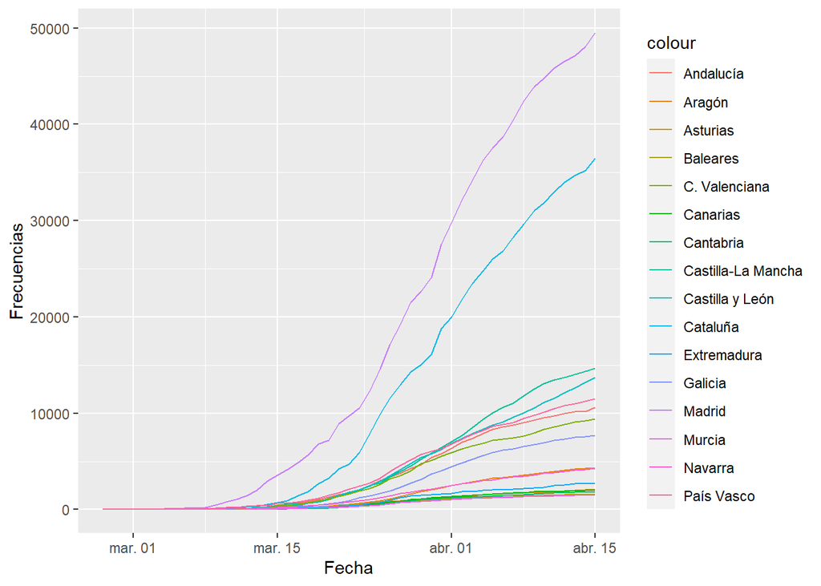

```r
x = data$fecha
ggplot(data, aes(x)) +
  geom_line(aes(y = Andalucía, colour = "Andalucía")) +
  geom_line(aes(y = Aragón, colour = "Aragón")) +
  geom_line(aes(y = Asturias, colour = "Asturias")) +
  geom_line(aes(y = Baleares, colour = "Baleares")) +
  geom_line(aes(y = Canarias, colour = "Canarias")) +
  geom_line(aes(y = Cantabria, colour = "Cantabria")) +
  geom_line(aes(y = `Castilla-La Mancha`, colour = "Castilla-La Mancha")) +
  geom_line(aes(y = `Castilla y León`, colour = "Castilla y León")) +
  geom_line(aes(y = Cataluña, colour = "Cataluña")) +
  geom_line(aes(y = `C. Valenciana`, colour = "C. Valenciana")) +
  geom_line(aes(y = Extremadura, colour = "Extremadura")) +
  geom_line(aes(y = Galicia, colour = "Galicia")) +
  geom_line(aes(y = Madrid, colour = "Madrid")) +
  geom_line(aes(y = Murcia, colour = "Murcia")) +
  geom_line(aes(y = Navarra, colour = "Navarra")) +
  geom_line(aes(y = `País Vasco`, colour = "País Vasco")) +
  xlab("Fecha") + ylab("Frecuencias")
```

## Pregunta 3

Para el día **15 de marzo de 2020** y suponiendo que la infección se ha expandido por igual en todas las comunidades autónomas hallar el **número de infectados esperado y empírico** para todas las comunidades autónomas.

```r
# No he entendido bien como realizar el procedimiento de este ejercicio, así que he copiado y pegado
fecha = "2020-03-15"

freq_emp = data[data$fecha==fecha & data$tipo=="casos", ]
freq_emp = freq_emp[c(-1, -2)]
freq_emp_sum = sum(freq_emp)

data2 = read.csv("data/Fichero_poblacionCCAA.csv")

pob_ccaa = data2$Pob_CCAA_2019
pob_total = sum(pob_ccaa)

freq_esperada = freq_emp_sum*data2$ccaa/pob_total
```

## Pregunta 4

Realizar el test $\chi^2$ correspondiente para testear si nuestra hipótesis de infección por igual es cierta o no y comentar los resultados obtenidos.

```r
chisq.test(freq_emp, p = freq_esperada/sum(freq_esperada))
```

[output not shown]

## Pregunta 5

Realizar las preguntas 3) y 4) pero para el día **4 de abril**.

```r
# No he entendido bien como realizar el procedimiento de este ejercicio, así que he copiado y pegado
fecha = "2020-04-04"

freq_emp = data[data$fecha==fecha & data$tipo=="casos", ]
freq_emp = freq_emp[c(-1, -2)]
freq_emp_sum = sum(freq_emp)

data2 = read.csv("data/Fichero_poblacionCCAA.csv")

pob_ccaa = data2$Pob_CCAA_2019
pob_total = sum(pob_ccaa)

freq_esperada = freq_emp_sum*data2$ccaa/pob_total
```

```r
chisq.test(freq_emp, p = freq_esperada/sum(freq_esperada))
```

[output not shown]

## Pregunta 6

Realizar las preguntas 1), 2), 3) y 4) pero en lugar de considerar el número de infectados, considerar el **número de fallecidos**.

```r
data <- read.csv("data/DatosCCAA.csv")
data$fecha %<>% ymd()

data %<>%
  select(fecha, CCAA, total, tipo) %>%
  pivot_wider(names_from = CCAA, values_from = total)

data = data[data$tipo == "fallecidos", ]

data %>%
  kable()
```

| fecha | tipo | Andalucía | Aragón | Asturias | Baleares | Canarias | Cantabria | Castilla-La Mancha | Castilla y León | Cataluña | C. Valenciana | Extremadura | Galicia | Madrid | Murcia | Navarra | País Vasco |
| --- | --- | --- | --- | --- | --- | --- | --- | --- | --- | --- | --- | --- | --- | --- | --- | --- | --- |
| 2020-03-03 | fallecidos | 0 | 0 | 0 | 0 | 0 | 0 | 0 | 0 | 0 | 0 | 0 | 0 | 0 | 0 | 0 | 0 |
| 2020-03-04 | fallecidos | 0 | 0 | 0 | 0 | 0 | 0 | 0 | 0 | 0 | 1 | 0 | 0 | 0 | 0 | 0 | 0 |
| 2020-03-05 | fallecidos | 0 | 0 | 0 | 0 | 0 | 0 | 0 | 0 | 0 | 1 | 0 | 0 | 1 | 0 | 0 | 1 |
| 2020-03-06 | fallecidos | 0 | 1 | 0 | 0 | 0 | 0 | 0 | 0 | 0 | 1 | 0 | 0 | 2 | 0 | 0 | 1 |
| 2020-03-07 | fallecidos | 0 | 1 | 0 | 0 | 0 | 0 | 0 | 0 | 1 | 1 | 0 | 0 | 4 | 0 | 0 | 1 |
| 2020-03-08 | fallecidos | 0 | 2 | 0 | 0 | 0 | 0 | 0 | 0 | 1 | 1 | 0 | 0 | 8 | 0 | 0 | 5 |
| 2020-03-09 | fallecidos | 0 | 2 | 0 | 0 | 0 | 0 | 0 | 0 | 1 | 1 | 0 | 0 | 8 | 0 | 0 | 5 |
| 2020-03-10 | fallecidos | 0 | 3 | 0 | 0 | 0 | 0 | 0 | 0 | 3 | 1 | 0 | 0 | 21 | 0 | 0 | 6 |
| 2020-03-11 | fallecidos | 0 | 4 | 0 | 0 | 0 | 0 | 0 | 0 | 3 | 1 | 0 | 0 | 31 | 0 | 0 | 6 |
| 2020-03-12 | fallecidos | 0 | 6 | 1 | 1 | 0 | 0 | 1 | 0 | 4 | 1 | 1 | 0 | 56 | 0 | 0 | 11 |
| 2020-03-13 | fallecidos | 0 | 7 | 1 | 1 | 0 | 0 | 5 | 1 | 4 | 1 | 1 | 0 | 81 | 0 | 0 | 14 |
| 2020-03-14 | fallecidos | 2 | 7 | 1 | 1 | 1 | 0 | 6 | 3 | 6 | 4 | 2 | 0 | 86 | 0 | 0 | 14 |
| 2020-03-15 | fallecidos | 6 | 7 | 1 | 1 | 1 | 0 | 10 | 6 | 8 | 5 | 2 | 2 | 213 | 0 | 0 | 23 |
| 2020-03-16 | fallecidos | 7 | 11 | 1 | 1 | 1 | 0 | 17 | 9 | 12 | 5 | 2 | 2 | 213 | 0 | 1 | 23 |
| 2020-03-17 | fallecidos | 11 | 12 | 1 | 1 | 2 | 0 | 17 | 12 | 18 | 13 | 3 | 3 | 355 | 0 | 2 | 36 |
| 2020-03-18 | fallecidos | 19 | 13 | 1 | 1 | 3 | 1 | 28 | 22 | 41 | 22 | 6 | 3 | 390 | 0 | 3 | 40 |
| 2020-03-19 | fallecidos | 23 | 15 | 1 | 2 | 3 | 1 | 42 | 29 | 55 | 24 | 8 | 4 | 498 | 0 | 4 | 53 |
| 2020-03-20 | fallecidos | 30 | 17 | 2 | 2 | 4 | 1 | 42 | 43 | 82 | 33 | 10 | 5 | 628 | 0 | 5 | 71 |
| 2020-03-21 | fallecidos | 40 | 22 | 5 | 4 | 7 | 2 | 84 | 55 | 122 | 50 | 12 | 9 | 804 | 1 | 9 | 85 |
| 2020-03-22 | fallecidos | 47 | 24 | 8 | 4 | 9 | 5 | 112 | 74 | 191 | 69 | 14 | 12 | 1021 | 1 | 14 | 97 |
| 2020-03-23 | fallecidos | 58 | 32 | 12 | 10 | 11 | 6 | 145 | 102 | 245 | 94 | 18 | 18 | 1263 | 2 | 24 | 120 |
| 2020-03-24 | fallecidos | 87 | 37 | 22 | 10 | 16 | 9 | 216 | 124 | 282 | 115 | 26 | 20 | 1535 | 3 | 31 | 133 |
| 2020-03-25 | fallecidos | 113 | 40 | 25 | 13 | 21 | 14 | 263 | 165 | 516 | 143 | 39 | 27 | 1825 | 5 | 33 | 155 |
| 2020-03-26 | fallecidos | 134 | 48 | 27 | 17 | 24 | 17 | 316 | 206 | 672 | 167 | 58 | 32 | 2090 | 8 | 49 | 180 |
| 2020-03-27 | fallecidos | 144 | 58 | 29 | 22 | 27 | 21 | 367 | 252 | 880 | 198 | 69 | 43 | 2412 | 15 | 58 | 207 |
| 2020-03-28 | fallecidos | 175 | 58 | 33 | 26 | 36 | 22 | 448 | 321 | 1070 | 234 | 88 | 47 | 2757 | 17 | 70 | 221 |
| 2020-03-29 | fallecidos | 207 | 93 | 41 | 29 | 39 | 26 | 539 | 380 | 1226 | 267 | 100 | 60 | 3082 | 20 | 84 | 265 |
| 2020-03-30 | fallecidos | 236 | 106 | 49 | 37 | 40 | 27 | 622 | 442 | 1410 | 310 | 106 | 66 | 3392 | 25 | 102 | 297 |
| 2020-03-31 | fallecidos | 248 | 138 | 55 | 42 | 55 | 37 | 708 | 516 | 1672 | 339 | 133 | 84 | 3603 | 34 | 113 | 325 |
| 2020-04-01 | fallecidos | 308 | 169 | 63 | 46 | 62 | 54 | 774 | 585 | 1849 | 395 | 152 | 103 | 3865 | 37 | 130 | 369 |
| 2020-04-02 | fallecidos | 343 | 200 | 69 | 58 | 68 | 60 | 854 | 641 | 2093 | 443 | 181 | 120 | 4175 | 42 | 141 | 412 |
| 2020-04-03 | fallecidos | 376 | 224 | 70 | 69 | 73 | 64 | 916 | 723 | 2335 | 511 | 200 | 138 | 4483 | 46 | 151 | 444 |
| 2020-04-04 | fallecidos | 426 | 251 | 76 | 71 | 78 | 68 | 989 | 786 | 2508 | 571 | 208 | 159 | 4723 | 51 | 171 | 477 |
| 2020-04-05 | fallecidos | 470 | 270 | 80 | 75 | 80 | 68 | 1055 | 847 | 2637 | 613 | 218 | 174 | 4941 | 59 | 178 | 515 |
| 2020-04-06 | fallecidos | 491 | 284 | 86 | 81 | 85 | 77 | 1132 | 919 | 2760 | 637 | 228 | 190 | 5136 | 68 | 187 | 548 |
| 2020-04-07 | fallecidos | 528 | 312 | 96 | 84 | 89 | 85 | 1177 | 982 | 2908 | 672 | 258 | 204 | 5371 | 78 | 202 | 586 |
| 2020-04-08 | fallecidos | 605 | 349 | 102 | 89 | 91 | 92 | 1255 | 1028 | 3041 | 724 | 271 | 213 | 5586 | 85 | 206 | 635 |
| 2020-04-09 | fallecidos | 652 | 385 | 110 | 89 | 92 | 98 | 1322 | 1082 | 3148 | 767 | 283 | 231 | 5800 | 88 | 214 | 689 |
| 2020-04-10 | fallecidos | 691 | 409 | 121 | 97 | 94 | 102 | 1431 | 1129 | 3231 | 796 | 288 | 243 | 5972 | 90 | 218 | 729 |
| 2020-04-11 | fallecidos | 737 | 425 | 128 | 102 | 95 | 107 | 1483 | 1180 | 3331 | 818 | 303 | 261 | 6084 | 94 | 227 | 765 |
| 2020-04-12 | fallecidos | 799 | 450 | 140 | 112 | 95 | 110 | 1543 | 1221 | 3442 | 838 | 312 | 274 | 6278 | 97 | 232 | 804 |
| 2020-04-13 | fallecidos | 815 | 464 | 149 | 117 | 96 | 117 | 1626 | 1263 | 3538 | 876 | 321 | 284 | 6423 | 101 | 239 | 831 |
| 2020-04-14 | fallecidos | 836 | 492 | 156 | 118 | 102 | 120 | 1714 | 1299 | 3666 | 907 | 334 | 290 | 6568 | 106 | 249 | 859 |
| 2020-04-15 | fallecidos | 865 | 514 | 166 | 125 | 104 | 132 | 1755 | 1337 | 3756 | 945 | 342 | 299 | 6724 | 109 | 252 | 902 |

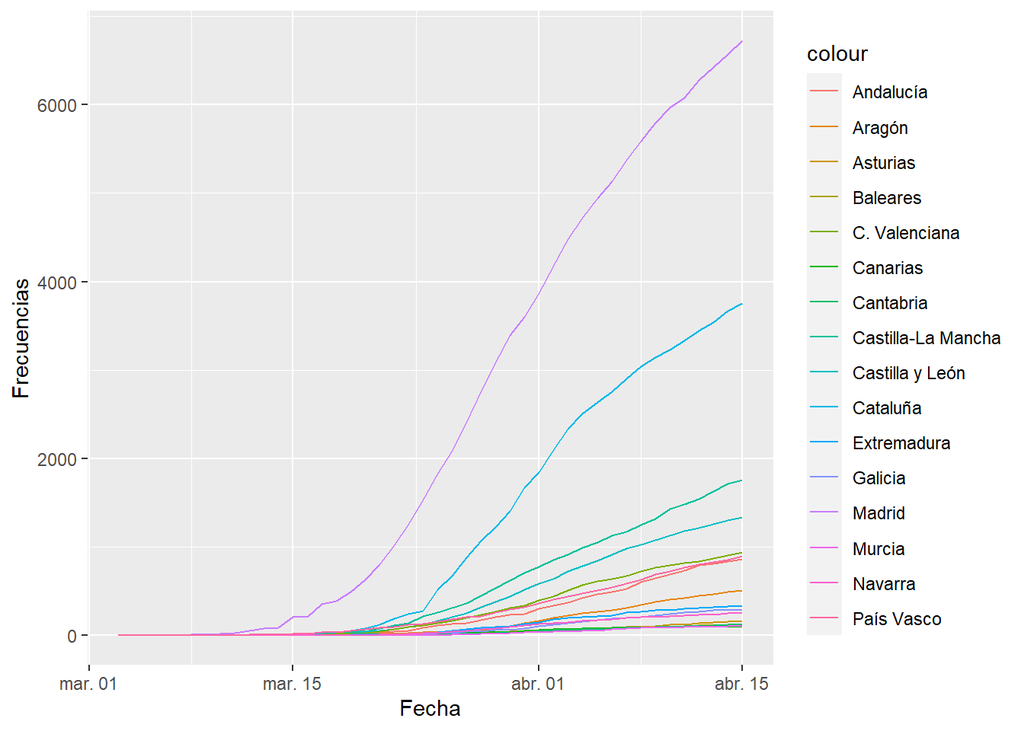

```r
x = data$fecha
ggplot(data, aes(x)) +
  geom_line(aes(y = Andalucía, colour = "Andalucía")) +
  geom_line(aes(y = Aragón, colour = "Aragón")) +
  geom_line(aes(y = Asturias, colour = "Asturias")) +
  geom_line(aes(y = Baleares, colour = "Baleares")) +
  geom_line(aes(y = Canarias, colour = "Canarias")) +
  geom_line(aes(y = Cantabria, colour = "Cantabria")) +
  geom_line(aes(y = `Castilla-La Mancha`, colour = "Castilla-La Mancha")) +
  geom_line(aes(y = `Castilla y León`, colour = "Castilla y León")) +
  geom_line(aes(y = Cataluña, colour = "Cataluña")) +
  geom_line(aes(y = `C. Valenciana`, colour = "C. Valenciana")) +
  geom_line(aes(y = Extremadura, colour = "Extremadura")) +
  geom_line(aes(y = Galicia, colour = "Galicia")) +
  geom_line(aes(y = Madrid, colour = "Madrid")) +
  geom_line(aes(y = Murcia, colour = "Murcia")) +
  geom_line(aes(y = Navarra, colour = "Navarra")) +
  geom_line(aes(y = `País Vasco`, colour = "País Vasco")) +
  xlab("Fecha") + ylab("Frecuencias")
```

```r
# No he entendido bien como realizar el procedimiento de este ejercicio, así que he copiado y pegado
fecha = "2020-03-15"

freq_emp = data[data$fecha==fecha & data$tipo=="fallecidos", ]
freq_emp = freq_emp[c(-1, -2)]
freq_emp_sum = sum(freq_emp)

data2 = read.csv("data/Fichero_poblacionCCAA.csv")

pob_ccaa = data2$Pob_CCAA_2019
pob_total = sum(pob_ccaa)

freq_esperada = freq_emp_sum*data2$ccaa/pob_total
```

```r
chisq.test(freq_emp, p = freq_esperada/sum(freq_esperada))
```

[output not shown]

## Pregunta 7

Realizar las preguntas 1), 2), 3) y 4) pero en lugar de considerar el número de infectados, considerar el **número de hospitalizados**.

```r
data <- read.csv("data/DatosCCAA.csv")
data$fecha %<>% ymd()

data %<>%
  select(fecha, CCAA, total, tipo) %>%
  pivot_wider(names_from = CCAA, values_from = total)

data = data[data$tipo == "hospitalizados", ]

data %>%
  kable()
```

| fecha | tipo | Andalucía | Aragón | Asturias | Baleares | Canarias | Cantabria | Castilla-La Mancha | Castilla y León | Cataluña | C. Valenciana | Extremadura | Galicia | Madrid | Murcia | Navarra | País Vasco |
| --- | --- | --- | --- | --- | --- | --- | --- | --- | --- | --- | --- | --- | --- | --- | --- | --- | --- |
| 2020-03-21 | hospitalizados | 605 | 192 | 133 | 60 | 139 | 92 | 635 | 575 | 1681 | 476 | 65 | 168 | 7388 | 61 | 222 | 654 |
| 2020-03-22 | hospitalizados | 724 | 241 | 171 | 79 | 150 | 116 | 838 | 709 | 1681 | 590 | 87 | 227 | 8441 | 78 | 288 | 988 |
| 2020-03-23 | hospitalizados | 865 | 298 | 194 | 87 | 172 | 157 | 1547 | 860 | 1681 | 702 | 131 | 270 | 9561 | 80 | 339 | 1252 |
| 2020-03-24 | hospitalizados | 1132 | 384 | 224 | 127 | 207 | 200 | 1826 | 1057 | 3599 | 917 | 161 | 338 | 10443 | 99 | 405 | 1425 |
| 2020-03-25 | hospitalizados | 1433 | 459 | 263 | 164 | 235 | 241 | 2162 | 1244 | 5434 | 1071 | 209 | 412 | 11153 | 127 | 506 | 1577 |
| 2020-03-26 | hospitalizados | 1626 | 562 | 300 | 205 | 279 | 300 | 2162 | 1515 | 7439 | 1278 | 241 | 503 | 12440 | 172 | 649 | 1907 |
| 2020-03-27 | hospitalizados | 1843 | 693 | 339 | 237 | 328 | 355 | 2707 | 1791 | 8545 | 1422 | 277 | 557 | 13580 | 209 | 732 | 2270 |
| 2020-03-28 | hospitalizados | 2106 | 835 | 408 | 283 | 377 | 406 | 2977 | 2063 | 9900 | 1694 | 312 | 906 | 14211 | 231 | 827 | 2612 |
| 2020-03-29 | hospitalizados | 2294 | 835 | 466 | 345 | 425 | 449 | 3018 | 2408 | 10688 | 1874 | 313 | 1043 | 14454 | 260 | 896 | 3106 |
| 2020-03-30 | hospitalizados | 2671 | 1094 | 479 | 353 | 444 | 481 | 3134 | 2540 | 11769 | 2042 | 353 | 1147 | 14917 | 265 | 955 | 3427 |
| 2020-03-31 | hospitalizados | 2867 | 1176 | 529 | 399 | 483 | 522 | 3225 | 2601 | 12974 | 2189 | 371 | 1250 | 15140 | 283 | 1035 | 3594 |
| 2020-04-01 | hospitalizados | 3147 | 1234 | 590 | 468 | 532 | 543 | 3230 | 2692 | 13969 | 2189 | 372 | 1338 | 15227 | 304 | 1120 | 3806 |
| 2020-04-02 | hospitalizados | 3444 | 1320 | 640 | 517 | 566 | 567 | 3230 | 2709 | 15489 | 2189 | 412 | 1447 | 15227 | 389 | 1181 | 4087 |
| 2020-04-03 | hospitalizados | 3673 | 1431 | 702 | 587 | 605 | 592 | 3168 | 2711 | 17257 | 2064 | 415 | 1630 | 15050 | 405 | 1284 | 4283 |
| 2020-04-04 | hospitalizados | 3896 | 1505 | 766 | 634 | 632 | 619 | 3133 | 2664 | 17678 | 1977 | 453 | 1767 | 14741 | 434 | 1341 | 4522 |
| 2020-04-05 | hospitalizados | 4107 | 1588 | 808 | 664 | 644 | 639 | 2950 | 2574 | 18656 | 1901 | 417 | 1831 | 14551 | 447 | 1399 | 4666 |
| 2020-04-06 | hospitalizados | 4227 | 1637 | 846 | 683 | 651 | 658 | 2901 | 2508 | 19143 | 1909 | 453 | 1916 | 14501 | 468 | 1432 | 4794 |
| 2020-04-07 | hospitalizados | 4335 | 1663 | 889 | 705 | 689 | 677 | 2908 | 5180 | 19745 | 1887 | 686 | 1968 | 13950 | 500 | 1488 | 4856 |
| 2020-04-08 | hospitalizados | 4463 | 1716 | 958 | 731 | 703 | 700 | 2731 | 5322 | 20250 | 1714 | 898 | 2014 | 13289 | 515 | 1526 | 4982 |
| 2020-04-09 | hospitalizados | 4599 | 1765 | 1018 | 751 | 730 | 720 | 2575 | 5523 | 20943 | 3815 | 958 | 2094 | 12853 | 533 | 1526 | 5130 |
| 2020-04-10 | hospitalizados | 4715 | 1822 | 1083 | 777 | 738 | 747 | 2359 | 5674 | 21530 | 3987 | 1003 | 2165 | 12432 | 533 | 1620 | 5290 |
| 2020-04-11 | hospitalizados | 4808 | 1860 | 1147 | 778 | 745 | 773 | 2198 | 5817 | 21921 | 4132 | 1052 | 2215 | 11894 | 533 | 1641 | 5402 |
| 2020-04-12 | hospitalizados | 4950 | 1901 | 1208 | 805 | 758 | 805 | 6838 | 5957 | 22369 | 4149 | 1074 | 2306 | 11424 | 537 | 1663 | 5547 |
| 2020-04-13 | hospitalizados | 4993 | 1938 | 1265 | 811 | 763 | 827 | 7782 | 6077 | 22780 | 4269 | 1096 | 2344 | 11233 | 543 | 1693 | 5622 |
| 2020-04-14 | hospitalizados | 5054 | 1966 | 1330 | 826 | 771 | 853 | 7830 | 6175 | 23126 | 4397 | 1114 | 2403 | 10753 | 566 | 1705 | 5679 |
| 2020-04-15 | hospitalizados | 5147 | 2006 | 1387 | 857 | 781 | 873 | 7896 | 6306 | 23372 | 4465 | 1155 | 2471 | 10116 | 574 | 1731 | 5750 |

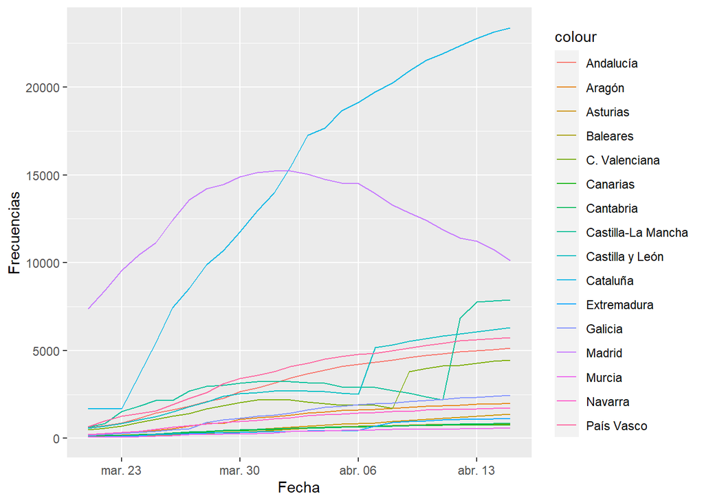

```r
x = data$fecha
ggplot(data, aes(x)) +
  geom_line(aes(y = Andalucía, colour = "Andalucía")) +
  geom_line(aes(y = Aragón, colour = "Aragón")) +
  geom_line(aes(y = Asturias, colour = "Asturias")) +
  geom_line(aes(y = Baleares, colour = "Baleares")) +
  geom_line(aes(y = Canarias, colour = "Canarias")) +
  geom_line(aes(y = Cantabria, colour = "Cantabria")) +
  geom_line(aes(y = `Castilla-La Mancha`, colour = "Castilla-La Mancha")) +
  geom_line(aes(y = `Castilla y León`, colour = "Castilla y León")) +
  geom_line(aes(y = Cataluña, colour = "Cataluña")) +
  geom_line(aes(y = `C. Valenciana`, colour = "C. Valenciana")) +
  geom_line(aes(y = Extremadura, colour = "Extremadura")) +
  geom_line(aes(y = Galicia, colour = "Galicia")) +
  geom_line(aes(y = Madrid, colour = "Madrid")) +
  geom_line(aes(y = Murcia, colour = "Murcia")) +
  geom_line(aes(y = Navarra, colour = "Navarra")) +
  geom_line(aes(y = `País Vasco`, colour = "País Vasco")) +
  xlab("Fecha") + ylab("Frecuencias")
```

```r
# No he entendido bien como realizar el procedimiento de este ejercicio, así que he copiado y pegado
fecha = "2020-03-15"

freq_emp = data[data$fecha==fecha & data$tipo=="hospitalizados", ]
freq_emp = freq_emp[c(-1, -2)]
freq_emp_sum = sum(freq_emp)

data2 = read.csv("data/Fichero_poblacionCCAA.csv")

pob_ccaa = data2$Pob_CCAA_2019
pob_total = sum(pob_ccaa)

freq_esperada = freq_emp_sum*data2$ccaa/pob_total
```

```r
chisq.test(freq_emp, p = freq_esperada/sum(freq_esperada))
```

[output not shown]